# BBWA (Bay-breasted Warbler)

Modified

March 4, 2025

Please add your feedback on each section of the model cycle.

**1. Species**

**Task:**

We would like to know if there are outliers and/or a truncation value that modelers might be aware of.

**Task:**

We would like to know if there are outliers and/or a truncation value that modelers might be aware of.

### Training data

**Task:**

Please identify misidentifications, migratory individuals, or surprises

**2. Covariates**

### Covariates relative importance BCR 71 (mean 10 bootstraps)

**Task**

Please re-rank covariates and/or suggest expected relative importance and/or percentage (%).

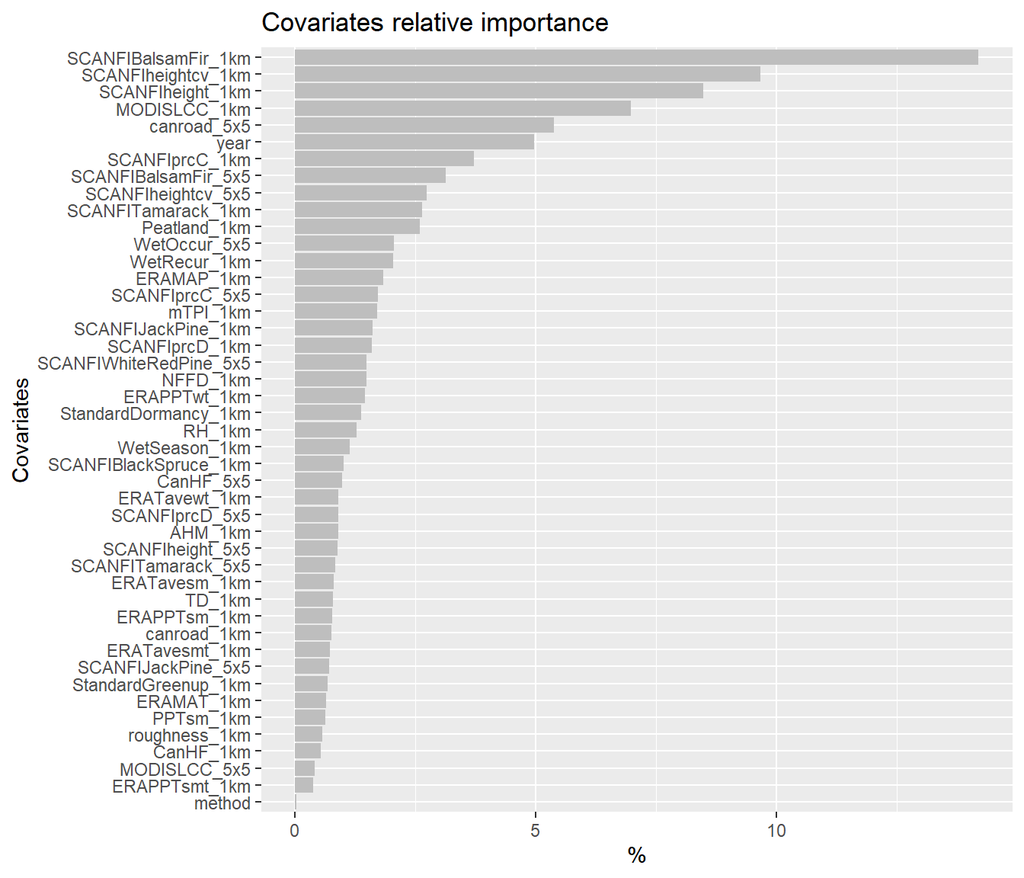

#### Covariates list an description

**Task:**

Task: Please suggest adding/removing covariates from the list.

| Covariate.label | bcr | value | Category | Native.resolution | Extraction.extent.for.model | Prediction.layer.resolution | Temporal.matching | Years.of.dataset | Data.provider | Citation | Source.URL | Description |
| --- | --- | --- | --- | --- | --- | --- | --- | --- | --- | --- | --- | --- |
| CanHF_1km | can71 | TRUE | Disturbance | 300 meters | 200 meters | 1 kilometer | no matching | 2020 *production year | University of Northern British Columbia | Hirsh-Pearson, Kristen; Johnson, Chris; Schuster, Richard; Wheate, Roger; Venter, Oscar, 2022, "The Canadian Human Footprint", https://doi.org/10.5683/SP2/EVKAVL, Borealis, V3 | https://borealisdata.ca/dataset.xhtml?persistentId=doi:10.5683/SP2/EVKAVL | Human footprint of Canada, created from global and national products and validated by high-resolution satellite imagery. |
| CanHF_5x5 | can71 | TRUE | Disturbance | 300 meters | 2000 meters | 5x5 convolution kernel | no matching | 2020 *production year | University of Northern British Columbia | Hirsh-Pearson, Kristen; Johnson, Chris; Schuster, Richard; Wheate, Roger; Venter, Oscar, 2022, "The Canadian Human Footprint", https://doi.org/10.5683/SP2/EVKAVL, Borealis, V4 | https://borealisdata.ca/dataset.xhtml?persistentId=doi:10.5683/SP2/EVKAVL | Human footprint of Canada, created from global and national products and validated by high-resolution satellite imagery. |
| canroad_1km | can71 | TRUE | Road | Line feature | point, on 1km2 raster | 1 kilometer | matched to nearest covariate year | 2001-2021 | Statistics Canada |  | https://www150.statcan.gc.ca/n1/en/catalogue/92-500-X | Canada road density derived from the Road Network File (RNF) prepared by Statistics Canada |
| canroad_5x5 | can71 | TRUE | Road | Line feature | point, on 1km2 raster | 5x5 convolution kernel | matched to nearest covariate year | 2001-2021 | Statistics Canada |  | https://www150.statcan.gc.ca/n1/en/catalogue/92-500-X | Canada road density derived from the Road Network File (RNF) prepared by Statistics Canada |
| CCNL_1km | can71 | TRUE | Disturbance | 1000 meters | point | 1 kilometer | matched to nearest covariate year | 1992-2013 | Beijng Normal University, Earth Observation Group, Payne Institute for Public Policy, Colorado School of Mines | Zhao,Chenchen, Cao,Xin, Chen,Xuehong, & Cui,Xihong. (2020). A Consistent and Corrected Nighttime Light dataset (CCNL 1992-2013) from DMSP-OLS data (Version 1.0) [Data set]. Zenodo. https://doi.org/10.… | https://developers.google.com/earth-engine/datasets/catalog/BNU_FGS_CCNL_v1 | Corrected nighttime light intensity reprocessed from the Defense Meteorological Program (DMSP) Operational Line-Scan System (OLS). DMSP data collected by US Air Force Weather Agency. |
| eFFP_1km | can71 | FALSE | Climate Normals | 1000 meters | point | 1 kilometer | no matching | Normal for 1991-2020 period | Centre for Forest Conservation Genetics, University of British Columbia | Wang, T., A. Hamann, D. Spittlehouse, C. Carroll. 2016. Locally Downscaled and Spatially Customizable Climate Data for Historical and Future Periods for North America. PLoS One 11(6): e0156720 https:/… | https://adaptwest.databasin.org/pages/adaptwest-climatena/ | The julian date on which the frost-free period ends, by ClimateNA, a software application that extracts and downscales gridded (4 x 4 km) monthly climate data for the reference normal period from PRIS… |
| ERAMAP_1km | can71 | TRUE | Annual Climate | 27830 meters | point | 1 kilometer | matched to previous covariate year | 1980-2019 | ECMWF / Copernicus Climate Change Service | Copernicus Climate Change Service (C3S) (2017): ERA5: Fifth generation of ECMWF atmospheric reanalyses of the global climate. Copernicus Climate Change Service Climate Data Store (CDS), (date of acces… | https://developers.google.com/earth-engine/datasets/catalog/ECMWF_ERA5_MONTHLY | Mean Annual Precipitation (MAP) derived from ERAS5, the fifth generation ECMWF atmospheric reanalysis of the global climate from 1940 to three months from real-time, the version in the EE Data Catalog… |
| ERAMAT_1km | can71 | TRUE | Annual Climate | 27830 meters | point | 1 kilometer | matched to previous covariate year | 1980-2019 | ECMWF / Copernicus Climate Change Service | Copernicus Climate Change Service (C3S) (2017): ERA5: Fifth generation of ECMWF atmospheric reanalyses of the global climate. Copernicus Climate Change Service Climate Data Store (CDS), (date of acces… | https://developers.google.com/earth-engine/datasets/catalog/ECMWF_ERA5_MONTHLY | Mean Annual Temperature (MAT) derived from ERAS5, the fifth generation ECMWF atmospheric reanalysis of the global climate from 1940 to three months from real-time, the version in the EE Data Catalog i… |
| ERAPPTsm_1km | can71 | TRUE | Annual Climate | 27830 meters | point | 1 kilometer | matched to previous covariate year | 1980-2019 | ECMWF / Copernicus Climate Change Service | Copernicus Climate Change Service (C3S) (2017): ERA5: Fifth generation of ECMWF atmospheric reanalyses of the global climate. Copernicus Climate Change Service Climate Data Store (CDS), (date of acces… | https://developers.google.com/earth-engine/datasets/catalog/ECMWF_ERA5_MONTHLY | Summer (Jun to Aug) (S) Precipitation derived from ERAS5, the fifth generation ECMWF atmospheric reanalysis of the global climate from 1940 to three months from real-time, the version in the EE Data C… |
| ERAPPTsmt_1km | can71 | TRUE | Annual Climate | 27830 meters | point | 1 kilometer | matched to nearest covariate year | 1980-2019 | ECMWF / Copernicus Climate Change Service | Copernicus Climate Change Service (C3S) (2017): ERA5: Fifth generation of ECMWF atmospheric reanalyses of the global climate. Copernicus Climate Change Service Climate Data Store (CDS), (date of acces… | https://developers.google.com/earth-engine/datasets/catalog/ECMWF_ERA5_MONTHLY | Summer (Jun to Aug) (S) Precipitation derived from ERAS5, the fifth generation ECMWF atmospheric reanalysis of the global climate from 1940 to three months from real-time, the version in the EE Data C… |
| ERAPPTwt_1km | can71 | TRUE | Annual Climate | 27830 meters | point | 1 kilometer | matched to previous covariate year | 1980-2019 | ECMWF / Copernicus Climate Change Service | Copernicus Climate Change Service (C3S) (2017): ERA5: Fifth generation of ECMWF atmospheric reanalyses of the global climate. Copernicus Climate Change Service Climate Data Store (CDS), (date of acces… | https://developers.google.com/earth-engine/datasets/catalog/ECMWF_ERA5_MONTHLY | Winter (Dec to Feb) (W) Precipitation derived from ERAS5, the fifth generation ECMWF atmospheric reanalysis of the global climate from 1940 to three months from real-time, the version in the EE Data C… |
| ERATavesm_1km | can71 | TRUE | Annual Climate | 27830 meters | point | 1 kilometer | matched to previous covariate year | 1980-2019 | ECMWF / Copernicus Climate Change Service | Copernicus Climate Change Service (C3S) (2017): ERA5: Fifth generation of ECMWF atmospheric reanalyses of the global climate. Copernicus Climate Change Service Climate Data Store (CDS), (date of acces… | https://developers.google.com/earth-engine/datasets/catalog/ECMWF_ERA5_MONTHLY | Summer (Jun to Aug) Mean (SM) Temperature derived from ERAS5, the fifth generation ECMWF atmospheric reanalysis of the global climate from 1940 to three months from real-time, the version in the EE Da… |
| ERATavesmt_1km | can71 | TRUE | Annual Climate | 27830 meters | point | 1 kilometer | matched to nearest covariate year | 1980-2019 | ECMWF / Copernicus Climate Change Service | Copernicus Climate Change Service (C3S) (2017): ERA5: Fifth generation of ECMWF atmospheric reanalyses of the global climate. Copernicus Climate Change Service Climate Data Store (CDS), (date of acces… | https://developers.google.com/earth-engine/datasets/catalog/ECMWF_ERA5_MONTHLY | Summer (Jun to Aug) Mean (SM) Temperature derived from ERAS5, the fifth generation ECMWF atmospheric reanalysis of the global climate from 1940 to three months from real-time, the version in the EE Da… |
| ERATavewt_1km | can71 | TRUE | Annual Climate | 27830 meters | point | 1 kilometer | matched to previous covariate year | 1980-2019 | ECMWF / Copernicus Climate Change Service | Copernicus Climate Change Service (C3S) (2017): ERA5: Fifth generation of ECMWF atmospheric reanalyses of the global climate. Copernicus Climate Change Service Climate Data Store (CDS), (date of acces… | https://developers.google.com/earth-engine/datasets/catalog/ECMWF_ERA5_MONTHLY | Winter (Dec to Feb) Mean (WM) temperature derived from ERAS5, the fifth generation ECMWF atmospheric reanalysis of the global climate from 1940 to three months from real-time, the version in the EE Da… |
| EXT_1km | can71 | FALSE | Climate Normals | 1000 meters | point | 1 kilometer | no matching | Normal for 1991-2020 period | Centre for Forest Conservation Genetics, University of British Columbia | Wang, T., A. Hamann, D. Spittlehouse, C. Carroll. 2016. Locally Downscaled and Spatially Customizable Climate Data for Historical and Future Periods for North America. PLoS One 11(6): e0156720 https:/… | https://adaptwest.databasin.org/pages/adaptwest-climatena/ | Extreme maximum temperature over 30 years, by ClimateNA, a software application that extracts and downscales gridded (4 x 4 km) monthly climate data for the reference normal period from PRISM and Worl… |
| MODISLCC_1km | can71 | TRUE | Landcover | 500 meters | point | 1 kilometer | matched to nearest covariate year | 2001-2020 | NASA LP DAAC | Friedl, M., Sulla-Menashe, D. (2022). MODIS/Terra+Aqua Land Cover Type Yearly L3 Global 500m SIN Grid V061 [Data set]. NASA EOSDIS Land Processes Distributed Active Archive Center. Accessed 2025-01-15… | https://developers.google.com/earth-engine/datasets/catalog/MODIS_061_MCD12Q1#description | Land Cover Type, produced by from classifications of spectro temporal features derived of data from the Moderate Resolution Imaging Spectroradiometer (MODIS). |
| MODISLCC_5x5 | can71 | TRUE | Landcover | 500 meters | 2000 meters, mode | 5x5 convolution kernel | matched to nearest covariate year | 2001-2020 | NASA LP DAAC | Friedl, M., Sulla-Menashe, D. (2022). MODIS/Terra+Aqua Land Cover Type Yearly L3 Global 500m SIN Grid V061 [Data set]. NASA EOSDIS Land Processes Distributed Active Archive Center. Accessed 2025-01-15… | https://developers.google.com/earth-engine/datasets/catalog/MODIS_061_MCD12Q1#description | Land Cover Type, produced by from classifications of spectro temporal features derived of data from the Moderate Resolution Imaging Spectroradiometer (MODIS). |
| mTPI_1km | can71 | TRUE | Topography | 1000 meters | point | 1 kilometer | no matching | 2018 *production year | Amatulli, G., Domisch, S., Tuanmu, M.-N., Parmentier, B., Ranipeta, A., Malczyk, J., and Jetz, W. (2018) A suite of global, cross-scale topographic variables for environmental and biodiversity modelin… | Amatulli, G., Domisch, S., Tuanmu, M.-N., Parmentier, B., Ranipeta, A., Malczyk, J., and Jetz, W. (2018) A suite of global, cross-scale topographic variables for environmental and biodiversity modelin… | https://www.earthenv.org/topography | Topographic position index (TPI), defined as the difference between the elevation of the focal cell and the mean elevation of the surrounding cells within a defined “neighborhood. |
| PAS_1km | can71 | FALSE | Climate Normals | 1000 meters | point | 1 kilometer | no matching | Normal for 1991-2020 period | Centre for Forest Conservation Genetics, University of British Columbia | Wang, T., A. Hamann, D. Spittlehouse, C. Carroll. 2016. Locally Downscaled and Spatially Customizable Climate Data for Historical and Future Periods for North America. PLoS One 11(6): e0156720 https:/… | https://adaptwest.databasin.org/pages/adaptwest-climatena/ | Precipitation as snow (mm), by ClimateNA, a software application that extracts and downscales gridded (4 x 4 km) monthly climate data for the reference normal period from PRISM and WorldClim to scale-… |
| Peatland_1km | can71 | TRUE | Wetland | 5 arcmin (appro. 9.3 km x 5.3 km in Canada) | point | 1 kilometer | no matching | 2022 *production year | Geoscientific Model Development | Melton, J. R., Chan, E., Millard, K., Fortier, M., Winton, R. S., Martín-López, J. M., Cadillo-Quiroz, H., Kidd, D., & Verchot, L. V. (2021). A map of global peatland extent created using machine lear… | https://zenodo.org/records/7352284#.Y9LpG-zMLpA | Peat, defined by the percent dead organic material by dry mass with lower minimum value of 30 %. |
| roughness_1km | can71 | TRUE | Topography | 100 meters | 200 meters | 1 kilometer | no matching | 2015 *production year | Michalak, J. L., Carroll, C., Nielsen, S. E., & Lawler, J. J. (2018). Land facet data for North America at 100m resolution. [Data set]. Zenodo. https://doi.org/10.5281/zenodo.1344637 | Michalak, J. L., Carroll, C., Nielsen, S. E., & Lawler, J. J. (2018). Land facet data for North America at 100m resolution. [Data set]. Zenodo. https://doi.org/10.5281/zenodo.1344639 | https://adaptwest.databasin.org/pages/adaptwest-landfacets/ | Roughness / Landforms were classified using a combination of Topographic Position Index (TPI) and slope based on the approach outlined in Jenness (2006). |
| SCANFI_1km | can71 | TRUE | Landcover | 30 meters | 200 meters, mode | 1 kilometer | matched to nearest covariate year | 1985, 1990, 1995, 2000, 2005, 2010, 2015, 2020 | Natural Resources Canada | Guindon L., Villemaire P., Correia D.L.P., Manka F., Lacarte S., Smiley B. 2023. SCANFI: Spatialized CAnadian National Forest Inventory data product. Natural Resources Canada, Canadian Forest Service,… | https://ouvert.canada.ca/data/dataset/18e6a919-53fd-41ce-b4e2-44a9707c52dc | Land cover class extracted from SCANFI: the Spatialized CAnadian National Forest Inventory data product, wall-to-wall maps |
| SCANFIBalsamFir_1km | can71 | TRUE | Biomass | 30 meters | 200 meters | 1 kilometer | matched to nearest covariate year | 1985, 1990, 1995, 2000, 2005, 2010, 2015, 2020 | Natural Resources Canada | Guindon L., Villemaire P., Correia D.L.P., Manka F., Lacarte S., Smiley B. 2023. SCANFI: Spatialized CAnadian National Forest Inventory data product. Natural Resources Canada, Canadian Forest Service,… | https://ouvert.canada.ca/data/dataset/18e6a919-53fd-41ce-b4e2-44a9707c52dc | Balsam fir tree cover in percentage extracted from SCANFI: the Spatialized CAnadian National Forest Inventory data product, wall-to-wall maps |
| SCANFIBalsamFir_5x5 | can71 | TRUE | Biomass | 30 meters | 2000 meters | 5x5 convolution kernel | matched to nearest covariate year | 1985, 1990, 1995, 2000, 2005, 2010, 2015, 2020 | Natural Resources Canada | Guindon L., Villemaire P., Correia D.L.P., Manka F., Lacarte S., Smiley B. 2023. SCANFI: Spatialized CAnadian National Forest Inventory data product. Natural Resources Canada, Canadian Forest Service,… | https://ouvert.canada.ca/data/dataset/18e6a919-53fd-41ce-b4e2-44a9707c52dc | Balsam fir tree cover in percentage extracted from SCANFI: the Spatialized CAnadian National Forest Inventory data product, wall-to-wall maps |
| SCANFIBlackSpruce_1km | can71 | TRUE | Biomass | 30 meters | 200 meters | 1 kilometer | matched to nearest covariate year | 1985, 1990, 1995, 2000, 2005, 2010, 2015, 2020 | Natural Resources Canada | Guindon L., Villemaire P., Correia D.L.P., Manka F., Lacarte S., Smiley B. 2023. SCANFI: Spatialized CAnadian National Forest Inventory data product. Natural Resources Canada, Canadian Forest Service,… | https://ouvert.canada.ca/data/dataset/18e6a919-53fd-41ce-b4e2-44a9707c52dc | Black spruce tree cover in percentage extracted from SCANFI: the Spatialized CAnadian National Forest Inventory data product, wall-to-wall maps |
| SCANFIDouglasFir_1km | can71 | TRUE | Biomass | 30 meters | 200 meters | 1 kilometer | matched to nearest covariate year | 1985, 1990, 1995, 2000, 2005, 2010, 2015, 2020 | Natural Resources Canada | Guindon L., Villemaire P., Correia D.L.P., Manka F., Lacarte S., Smiley B. 2023. SCANFI: Spatialized CAnadian National Forest Inventory data product. Natural Resources Canada, Canadian Forest Service,… | https://ouvert.canada.ca/data/dataset/18e6a919-53fd-41ce-b4e2-44a9707c52dc | Douglas fir tree cover in percentage extracted from SCANFI: the Spatialized CAnadian National Forest Inventory data product, wall-to-wall maps |
| SCANFIDouglasFir_5x5 | can71 | TRUE | Biomass | 30 meters | 2000 meters | 5x5 convolution kernel | matched to nearest covariate year | 1985, 1990, 1995, 2000, 2005, 2010, 2015, 2020 | Natural Resources Canada | Guindon L., Villemaire P., Correia D.L.P., Manka F., Lacarte S., Smiley B. 2023. SCANFI: Spatialized CAnadian National Forest Inventory data product. Natural Resources Canada, Canadian Forest Service,… | https://ouvert.canada.ca/data/dataset/18e6a919-53fd-41ce-b4e2-44a9707c52dc | Douglas fir tree cover in percentage extracted from SCANFI: the Spatialized CAnadian National Forest Inventory data product, wall-to-wall maps |
| SCANFIheight_1km | can71 | TRUE | Biomass | 30 meters | 200 meters | 1 kilometer | matched to nearest covariate year | 1985, 1990, 1995, 2000, 2005, 2010, 2015, 2020 | Natural Resources Canada | Guindon L., Villemaire P., Correia D.L.P., Manka F., Lacarte S., Smiley B. 2023. SCANFI: Spatialized CAnadian National Forest Inventory data product. Natural Resources Canada, Canadian Forest Service,… | https://ouvert.canada.ca/data/dataset/18e6a919-53fd-41ce-b4e2-44a9707c52dc | Height (meters): vegetation height extracted from SCANFI: the Spatialized CAnadian National Forest Inventory data product, wall-to-wall maps |
| SCANFIheight_5x5 | can71 | TRUE | Biomass | 30 meters | 2000 meters | 5x5 convolution kernel | matched to nearest covariate year | 1985, 1990, 1995, 2000, 2005, 2010, 2015, 2020 | Natural Resources Canada | Guindon L., Villemaire P., Correia D.L.P., Manka F., Lacarte S., Smiley B. 2023. SCANFI: Spatialized CAnadian National Forest Inventory data product. Natural Resources Canada, Canadian Forest Service,… | https://ouvert.canada.ca/data/dataset/18e6a919-53fd-41ce-b4e2-44a9707c52dc | Height (meters): vegetation height extracted from SCANFI: the Spatialized CAnadian National Forest Inventory data product, wall-to-wall maps |
| SCANFIheightcv_1km | can71 | TRUE | Biomass | 30 meters | 200 meters | 1 kilometer | matched to nearest covariate year | 1985, 1990, 1995, 2000, 2005, 2010, 2015, 2020 | Natural Resources Canada | Guindon L., Villemaire P., Correia D.L.P., Manka F., Lacarte S., Smiley B. 2023. SCANFI: Spatialized CAnadian National Forest Inventory data product. Natural Resources Canada, Canadian Forest Service,… | https://ouvert.canada.ca/data/dataset/18e6a919-53fd-41ce-b4e2-44a9707c52dc | Coefficient of variation (CV) of Height (meters): vegetation height extracted from SCANFI: the Spatialized CAnadian National Forest Inventory data product, wall-to-wall maps |
| SCANFIheightcv_5x5 | can71 | TRUE | Biomass | 30 meters | 2000 meters | 5x5 convolution kernel | matched to nearest covariate year | 1985, 1990, 1995, 2000, 2005, 2010, 2015, 2020 | Natural Resources Canada | Guindon L., Villemaire P., Correia D.L.P., Manka F., Lacarte S., Smiley B. 2023. SCANFI: Spatialized CAnadian National Forest Inventory data product. Natural Resources Canada, Canadian Forest Service,… | https://ouvert.canada.ca/data/dataset/18e6a919-53fd-41ce-b4e2-44a9707c52dc | Coefficient of variation (CV) of Height (meters): vegetation height extracted from SCANFI: the Spatialized CAnadian National Forest Inventory data product, wall-to-wall maps |
| SCANFIJackPine_1km | can71 | TRUE | Biomass | 30 meters | 200 meters | 1 kilometer | matched to nearest covariate year | 1985, 1990, 1995, 2000, 2005, 2010, 2015, 2020 | Natural Resources Canada | Guindon L., Villemaire P., Correia D.L.P., Manka F., Lacarte S., Smiley B. 2023. SCANFI: Spatialized CAnadian National Forest Inventory data product. Natural Resources Canada, Canadian Forest Service,… | https://ouvert.canada.ca/data/dataset/18e6a919-53fd-41ce-b4e2-44a9707c52dc | Jack pine tree cover in percentage extracted from SCANFI: the Spatialized CAnadian National Forest Inventory data product, wall-to-wall maps |
| SCANFIJackPine_5x5 | can71 | TRUE | Biomass | 30 meters | 2000 meters | 5x5 convolution kernel | matched to nearest covariate year | 1985, 1990, 1995, 2000, 2005, 2010, 2015, 2020 | Natural Resources Canada | Guindon L., Villemaire P., Correia D.L.P., Manka F., Lacarte S., Smiley B. 2023. SCANFI: Spatialized CAnadian National Forest Inventory data product. Natural Resources Canada, Canadian Forest Service,… | https://ouvert.canada.ca/data/dataset/18e6a919-53fd-41ce-b4e2-44a9707c52dc | Jack pine tree cover in percentage extracted from SCANFI: the Spatialized CAnadian National Forest Inventory data product, wall-to-wall maps |
| SCANFILodgepolePine_1km | can71 | TRUE | Biomass | 30 meters | 200 meters | 1 kilometer | matched to nearest covariate year | 1985, 1990, 1995, 2000, 2005, 2010, 2015, 2020 | Natural Resources Canada | Guindon L., Villemaire P., Correia D.L.P., Manka F., Lacarte S., Smiley B. 2023. SCANFI: Spatialized CAnadian National Forest Inventory data product. Natural Resources Canada, Canadian Forest Service,… | https://ouvert.canada.ca/data/dataset/18e6a919-53fd-41ce-b4e2-44a9707c52dc | Lodgepole pine tree cover in percentage extracted from SCANFI: the Spatialized CAnadian National Forest Inventory data product, wall-to-wall maps |
| SCANFILodgepolePine_5x5 | can71 | TRUE | Biomass | 30 meters | 2000 meters | 5x5 convolution kernel | matched to nearest covariate year | 1985, 1990, 1995, 2000, 2005, 2010, 2015, 2020 | Natural Resources Canada | Guindon L., Villemaire P., Correia D.L.P., Manka F., Lacarte S., Smiley B. 2023. SCANFI: Spatialized CAnadian National Forest Inventory data product. Natural Resources Canada, Canadian Forest Service,… | https://ouvert.canada.ca/data/dataset/18e6a919-53fd-41ce-b4e2-44a9707c52dc | Lodgepole pine tree cover in percentage extracted from SCANFI: the Spatialized CAnadian National Forest Inventory data product, wall-to-wall maps |
| SCANFIPonderosaPine_1km | can71 | TRUE | Biomass | 30 meters | 200 meters | 1 kilometer | matched to nearest covariate year | 1985, 1990, 1995, 2000, 2005, 2010, 2015, 2020 | Natural Resources Canada | Guindon L., Villemaire P., Correia D.L.P., Manka F., Lacarte S., Smiley B. 2023. SCANFI: Spatialized CAnadian National Forest Inventory data product. Natural Resources Canada, Canadian Forest Service,… | https://ouvert.canada.ca/data/dataset/18e6a919-53fd-41ce-b4e2-44a9707c52dc | Ponderosa pine tree cover in percentage extracted from SCANFI: the Spatialized CAnadian National Forest Inventory data product, wall-to-wall maps |
| SCANFIPonderosaPine_5x5 | can71 | TRUE | Biomass | 30 meters | 2000 meters | 5x5 convolution kernel | matched to nearest covariate year | 1985, 1990, 1995, 2000, 2005, 2010, 2015, 2020 | Natural Resources Canada | Guindon L., Villemaire P., Correia D.L.P., Manka F., Lacarte S., Smiley B. 2023. SCANFI: Spatialized CAnadian National Forest Inventory data product. Natural Resources Canada, Canadian Forest Service,… | https://ouvert.canada.ca/data/dataset/18e6a919-53fd-41ce-b4e2-44a9707c52dc | Ponderosa pine tree cover in percentage extracted from SCANFI: the Spatialized CAnadian National Forest Inventory data product, wall-to-wall maps |
| SCANFIprcC_1km | can71 | TRUE | Biomass | 30 meters | 200 meters | 1 kilometer | matched to nearest covariate year | 1985, 1990, 1995, 2000, 2005, 2010, 2015, 2020 | Natural Resources Canada | Guindon L., Villemaire P., Correia D.L.P., Manka F., Lacarte S., Smiley B. 2023. SCANFI: Spatialized CAnadian National Forest Inventory data product. Natural Resources Canada, Canadian Forest Service,… | https://ouvert.canada.ca/data/dataset/18e6a919-53fd-41ce-b4e2-44a9707c52dc | Other coniferous tree cover in percentage extracted from SCANFI: the Spatialized CAnadian National Forest Inventory data product, wall-to-wall maps |
| SCANFIprcC_5x5 | can71 | TRUE | Biomass | 30 meters | 2000 meters | 5x5 convolution kernel | matched to nearest covariate year | 1985, 1990, 1995, 2000, 2005, 2010, 2015, 2020 | Natural Resources Canada | Guindon L., Villemaire P., Correia D.L.P., Manka F., Lacarte S., Smiley B. 2023. SCANFI: Spatialized CAnadian National Forest Inventory data product. Natural Resources Canada, Canadian Forest Service,… | https://ouvert.canada.ca/data/dataset/18e6a919-53fd-41ce-b4e2-44a9707c52dc | Other coniferous tree cover in percentage extracted from SCANFI: the Spatialized CAnadian National Forest Inventory data product, wall-to-wall maps |
| SCANFIprcD_1km | can71 | TRUE | Biomass | 30 meters | 200 meters | 1 kilometer | matched to nearest covariate year | 1985, 1990, 1995, 2000, 2005, 2010, 2015, 2020 | Natural Resources Canada | Guindon L., Villemaire P., Correia D.L.P., Manka F., Lacarte S., Smiley B. 2023. SCANFI: Spatialized CAnadian National Forest Inventory data product. Natural Resources Canada, Canadian Forest Service,… | https://ouvert.canada.ca/data/dataset/18e6a919-53fd-41ce-b4e2-44a9707c52dc | Broadleaf tree cover in percentage extracted from SCANFI: the Spatialized CAnadian National Forest Inventory data product, wall-to-wall maps |
| SCANFIprcD_5x5 | can71 | TRUE | Biomass | 30 meters | 2000 meters | 5x5 convolution kernel | matched to nearest covariate year | 1985, 1990, 1995, 2000, 2005, 2010, 2015, 2020 | Natural Resources Canada | Guindon L., Villemaire P., Correia D.L.P., Manka F., Lacarte S., Smiley B. 2023. SCANFI: Spatialized CAnadian National Forest Inventory data product. Natural Resources Canada, Canadian Forest Service,… | https://ouvert.canada.ca/data/dataset/18e6a919-53fd-41ce-b4e2-44a9707c52dc | Broadleaf tree cover in percentage extracted from SCANFI: the Spatialized CAnadian National Forest Inventory data product, wall-to-wall maps |
| SCANFITamarack_1km | can71 | TRUE | Biomass | 30 meters | 200 meters | 1 kilometer | matched to nearest covariate year | 1985, 1990, 1995, 2000, 2005, 2010, 2015, 2020 | Natural Resources Canada | Guindon L., Villemaire P., Correia D.L.P., Manka F., Lacarte S., Smiley B. 2023. SCANFI: Spatialized CAnadian National Forest Inventory data product. Natural Resources Canada, Canadian Forest Service,… | https://ouvert.canada.ca/data/dataset/18e6a919-53fd-41ce-b4e2-44a9707c52dc | Tamarack tree cover in percentage extracted from SCANFI: the Spatialized CAnadian National Forest Inventory data product, wall-to-wall maps |
| SCANFITamarack_5x5 | can71 | TRUE | Biomass | 30 meters | 2000 meters | 5x5 convolution kernel | matched to nearest covariate year | 1985, 1990, 1995, 2000, 2005, 2010, 2015, 2020 | Natural Resources Canada | Guindon L., Villemaire P., Correia D.L.P., Manka F., Lacarte S., Smiley B. 2023. SCANFI: Spatialized CAnadian National Forest Inventory data product. Natural Resources Canada, Canadian Forest Service,… | https://ouvert.canada.ca/data/dataset/18e6a919-53fd-41ce-b4e2-44a9707c52dc | Tamarack tree cover in percentage extracted from SCANFI: the Spatialized CAnadian National Forest Inventory data product, wall-to-wall maps |
| SCANFIWhiteRedPine_1km | can71 | TRUE | Biomass | 30 meters | 200 meters | 1 kilometer | matched to nearest covariate year | 1985, 1990, 1995, 2000, 2005, 2010, 2015, 2020 | Natural Resources Canada | Guindon L., Villemaire P., Correia D.L.P., Manka F., Lacarte S., Smiley B. 2023. SCANFI: Spatialized CAnadian National Forest Inventory data product. Natural Resources Canada, Canadian Forest Service,… | https://ouvert.canada.ca/data/dataset/18e6a919-53fd-41ce-b4e2-44a9707c52dc | White and red pine tree cover in percentage extracted from SCANFI: the Spatialized CAnadian National Forest Inventory data product, wall-to-wall maps |
| SCANFIWhiteRedPine_5x5 | can71 | TRUE | Biomass | 30 meters | 2000 meters | 5x5 convolution kernel | matched to nearest covariate year | 1985, 1990, 1995, 2000, 2005, 2010, 2015, 2020 | Natural Resources Canada | Guindon L., Villemaire P., Correia D.L.P., Manka F., Lacarte S., Smiley B. 2023. SCANFI: Spatialized CAnadian National Forest Inventory data product. Natural Resources Canada, Canadian Forest Service,… | https://ouvert.canada.ca/data/dataset/18e6a919-53fd-41ce-b4e2-44a9707c52dc | White and red pine tree cover in percentage extracted from SCANFI: the Spatialized CAnadian National Forest Inventory data product, wall-to-wall maps |
| SHM_1km | can71 | FALSE | Climate Normals | 1000 meters | point | 1 kilometer | no matching | Normal for 1991-2020 period | Centre for Forest Conservation Genetics, University of British Columbia | Wang, T., A. Hamann, D. Spittlehouse, C. Carroll. 2016. Locally Downscaled and Spatially Customizable Climate Data for Historical and Future Periods for North America. PLoS One 11(6): e0156720 https:/… | https://adaptwest.databasin.org/pages/adaptwest-climatena/ | Summer heat moisture index, calculated as MWMT/(MSP/1000), by ClimateNA, a software application that extracts and downscales gridded (4 x 4 km) monthly climate data for the reference normal period fro… |
| StandardDormancy_1km | can71 | TRUE | Greenup | 500 meters | point | 1 kilometer | matched to nearest covariate year | 2001-2019 | NASA LP DAAC | Friedl, M., Gray, J., Sulla-Menashe, D. (2022). MODIS/Terra+Aqua Land Cover Dynamics Yearly L3 Global 500m SIN Grid V061 [Data set]. NASA EOSDIS Land Processes Distributed Active Archive Center. Acces… | https://developers.google.com/earth-engine/datasets/catalog/MODIS_061_MCD12Q2#description | Dormancy, the Date when EVI2 last crossed 15% of the segment EVI2 amplitude, derived from MODIS imagery. |
| StandardGreenup_1km | can71 | TRUE | Greenup | 500 meters | point | 1 kilometer | matched to nearest covariate year | 2001-2019 | NASA LP DAAC | Friedl, M., Gray, J., Sulla-Menashe, D. (2022). MODIS/Terra+Aqua Land Cover Dynamics Yearly L3 Global 500m SIN Grid V061 [Data set]. NASA EOSDIS Land Processes Distributed Active Archive Center. Acces… | https://developers.google.com/earth-engine/datasets/catalog/MODIS_061_MCD12Q2#description | Greenup, the Date when EVI2 first crossed 15% of the segment EVI2 amplitude, derived from MODIS imagery. |
| TD_1km | can71 | TRUE | Climate Normals | 1000 meters | point | 1 kilometer | no matching | Normal for 1991-2020 period | Centre for Forest Conservation Genetics, University of British Columbia | Wang, T., A. Hamann, D. Spittlehouse, C. Carroll. 2016. Locally Downscaled and Spatially Customizable Climate Data for Historical and Future Periods for North America. PLoS One 11(6): e0156720 https:/… | https://adaptwest.databasin.org/pages/adaptwest-climatena/ | Difference between MCMT and MWMT, as a measure of continentality (°C), by ClimateNA, a software application that extracts and downscales gridded (4 x 4 km) monthly climate data for the reference norma… |
| VLCE_1km | can71 | TRUE | Landcover | 30 meters | 200 meters, mode | 1 kilometer | matched to nearest covariate year | 1984-2019 | Canadian Forest Service (Pacific Forestry Centre), Natural Resources, Canada | Hermosilla, T., Wulder, M. A., White, J. C., Coops, N. C., & Hobart, G. W. (2018). Disturbance-Informed Annual Land Cover Classification Maps of Canada’s Forested Ecosystems for a 29-Year Landsat Time… | https://opendata.nfis.org/mapserver/nfis-change_eng.html | High-resolution annual forest land cover maps for Canada's forested ecosystems (1984-2022). |
| WetOccur_5x5 | can71 | TRUE | Wetland | 30 meters, downsize to 350 meters | 2000 meters | 5x5 convolution kernel | no matching | Aggragate between 1984-2021 | European Commission's Joint Research Centre, UN Environment, Google | Jean-Francois Pekel, Andrew Cottam, Noel Gorelick, Alan S. Belward, High-resolution mapping of global surface water and its long-term changes. Nature 540, 418-422 (2016). (doi:10.1038/nature20584) | https://developers.google.com/earth-engine/datasets/catalog/JRC_GSW1_4_GlobalSurfaceWater | Occurence (The frequency with which water was present), where surface water occurred between 1984 and 2021. |
| WetRecur_1km | can71 | TRUE | Wetland | 30 meters, downsize to 350 meters | 200 meters | 1 kilometer | no matching | Aggragate between 1984-2021 | European Commission's Joint Research Centre, UN Environment, Google | Jean-Francois Pekel, Andrew Cottam, Noel Gorelick, Alan S. Belward, High-resolution mapping of global surface water and its long-term changes. Nature 540, 418-422 (2016). (doi:10.1038/nature20584) | https://developers.google.com/earth-engine/datasets/catalog/JRC_GSW1_4_GlobalSurfaceWater | Recurrence (The frequency with which water returns from year to year), concerning the inter-annual behavior of water surfaces and captures the frequency with which water returns from year to year. |
| WetSeason_1km | can71 | TRUE | Wetland | 30 meters, downsize to 350 meters | 200 meters | 5x5 convolution kernel | no matching | Aggragate between 1984-2021 | European Commission's Joint Research Centre, UN Environment, Google | Jean-Francois Pekel, Andrew Cottam, Noel Gorelick, Alan S. Belward, High-resolution mapping of global surface water and its long-term changes. Nature 540, 418-422 (2016). (doi:10.1038/nature20584) | https://developers.google.com/earth-engine/datasets/catalog/JRC_GSW1_4_GlobalSurfaceWater | Seasonality (Number of months water is present), concerning the intra-annual behaviour of water surfaces for a single year. |

### Covariates relative importance BCR 81 (mean 10 boostraps)

**Task:**

Please re-rank covariates and/or suggest expected relative importance and/or percentage (%).

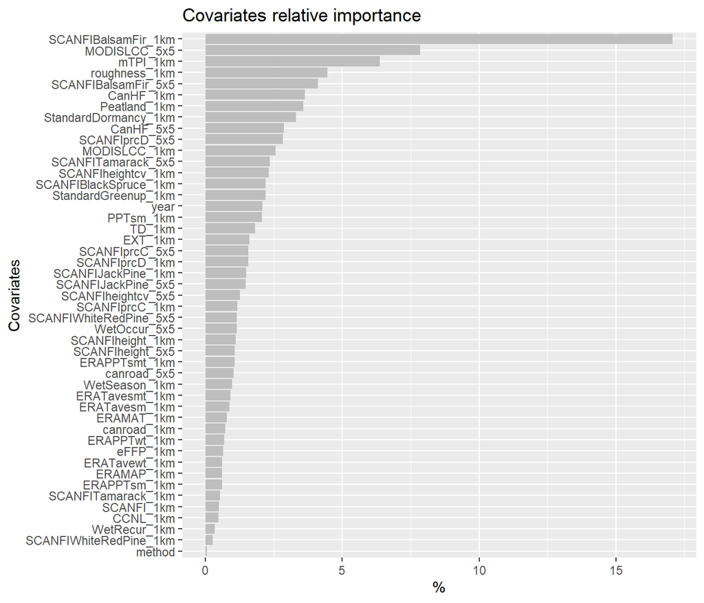

#### Covariates list an description

**Task:**

Please suggest adding/removing covariates from the list.

| Covariate.label | bcr | value | Category | Native.resolution | Extraction.extent.for.model | Prediction.layer.resolution | Temporal.matching | Years.of.dataset | Data.provider | Citation | Source.URL | Description |
| --- | --- | --- | --- | --- | --- | --- | --- | --- | --- | --- | --- | --- |
| CanHF_1km | can81 | TRUE | Disturbance | 300 meters | 200 meters | 1 kilometer | no matching | 2020 *production year | University of Northern British Columbia | Hirsh-Pearson, Kristen; Johnson, Chris; Schuster, Richard; Wheate, Roger; Venter, Oscar, 2022, "The Canadian Human Footprint", https://doi.org/10.5683/SP2/EVKAVL, Borealis, V3 | https://borealisdata.ca/dataset.xhtml?persistentId=doi:10.5683/SP2/EVKAVL | Human footprint of Canada, created from global and national products and validated by high-resolution satellite imagery. |
| CanHF_5x5 | can81 | TRUE | Disturbance | 300 meters | 2000 meters | 5x5 convolution kernel | no matching | 2020 *production year | University of Northern British Columbia | Hirsh-Pearson, Kristen; Johnson, Chris; Schuster, Richard; Wheate, Roger; Venter, Oscar, 2022, "The Canadian Human Footprint", https://doi.org/10.5683/SP2/EVKAVL, Borealis, V4 | https://borealisdata.ca/dataset.xhtml?persistentId=doi:10.5683/SP2/EVKAVL | Human footprint of Canada, created from global and national products and validated by high-resolution satellite imagery. |
| canroad_1km | can81 | TRUE | Road | Line feature | point, on 1km2 raster | 1 kilometer | matched to nearest covariate year | 2001-2021 | Statistics Canada |  | https://www150.statcan.gc.ca/n1/en/catalogue/92-500-X | Canada road density derived from the Road Network File (RNF) prepared by Statistics Canada |
| canroad_5x5 | can81 | TRUE | Road | Line feature | point, on 1km2 raster | 5x5 convolution kernel | matched to nearest covariate year | 2001-2021 | Statistics Canada |  | https://www150.statcan.gc.ca/n1/en/catalogue/92-500-X | Canada road density derived from the Road Network File (RNF) prepared by Statistics Canada |
| CCNL_1km | can81 | TRUE | Disturbance | 1000 meters | point | 1 kilometer | matched to nearest covariate year | 1992-2013 | Beijng Normal University, Earth Observation Group, Payne Institute for Public Policy, Colorado School of Mines | Zhao,Chenchen, Cao,Xin, Chen,Xuehong, & Cui,Xihong. (2020). A Consistent and Corrected Nighttime Light dataset (CCNL 1992-2013) from DMSP-OLS data (Version 1.0) [Data set]. Zenodo. https://doi.org/10.… | https://developers.google.com/earth-engine/datasets/catalog/BNU_FGS_CCNL_v1 | Corrected nighttime light intensity reprocessed from the Defense Meteorological Program (DMSP) Operational Line-Scan System (OLS). DMSP data collected by US Air Force Weather Agency. |
| eFFP_1km | can81 | TRUE | Climate Normals | 1000 meters | point | 1 kilometer | no matching | Normal for 1991-2020 period | Centre for Forest Conservation Genetics, University of British Columbia | Wang, T., A. Hamann, D. Spittlehouse, C. Carroll. 2016. Locally Downscaled and Spatially Customizable Climate Data for Historical and Future Periods for North America. PLoS One 11(6): e0156720 https:/… | https://adaptwest.databasin.org/pages/adaptwest-climatena/ | The julian date on which the frost-free period ends, by ClimateNA, a software application that extracts and downscales gridded (4 x 4 km) monthly climate data for the reference normal period from PRIS… |
| ERAMAP_1km | can81 | TRUE | Annual Climate | 27830 meters | point | 1 kilometer | matched to previous covariate year | 1980-2019 | ECMWF / Copernicus Climate Change Service | Copernicus Climate Change Service (C3S) (2017): ERA5: Fifth generation of ECMWF atmospheric reanalyses of the global climate. Copernicus Climate Change Service Climate Data Store (CDS), (date of acces… | https://developers.google.com/earth-engine/datasets/catalog/ECMWF_ERA5_MONTHLY | Mean Annual Precipitation (MAP) derived from ERAS5, the fifth generation ECMWF atmospheric reanalysis of the global climate from 1940 to three months from real-time, the version in the EE Data Catalog… |
| ERAMAT_1km | can81 | TRUE | Annual Climate | 27830 meters | point | 1 kilometer | matched to previous covariate year | 1980-2019 | ECMWF / Copernicus Climate Change Service | Copernicus Climate Change Service (C3S) (2017): ERA5: Fifth generation of ECMWF atmospheric reanalyses of the global climate. Copernicus Climate Change Service Climate Data Store (CDS), (date of acces… | https://developers.google.com/earth-engine/datasets/catalog/ECMWF_ERA5_MONTHLY | Mean Annual Temperature (MAT) derived from ERAS5, the fifth generation ECMWF atmospheric reanalysis of the global climate from 1940 to three months from real-time, the version in the EE Data Catalog i… |
| ERAPPTsm_1km | can81 | TRUE | Annual Climate | 27830 meters | point | 1 kilometer | matched to previous covariate year | 1980-2019 | ECMWF / Copernicus Climate Change Service | Copernicus Climate Change Service (C3S) (2017): ERA5: Fifth generation of ECMWF atmospheric reanalyses of the global climate. Copernicus Climate Change Service Climate Data Store (CDS), (date of acces… | https://developers.google.com/earth-engine/datasets/catalog/ECMWF_ERA5_MONTHLY | Summer (Jun to Aug) (S) Precipitation derived from ERAS5, the fifth generation ECMWF atmospheric reanalysis of the global climate from 1940 to three months from real-time, the version in the EE Data C… |
| ERAPPTsmt_1km | can81 | TRUE | Annual Climate | 27830 meters | point | 1 kilometer | matched to nearest covariate year | 1980-2019 | ECMWF / Copernicus Climate Change Service | Copernicus Climate Change Service (C3S) (2017): ERA5: Fifth generation of ECMWF atmospheric reanalyses of the global climate. Copernicus Climate Change Service Climate Data Store (CDS), (date of acces… | https://developers.google.com/earth-engine/datasets/catalog/ECMWF_ERA5_MONTHLY | Summer (Jun to Aug) (S) Precipitation derived from ERAS5, the fifth generation ECMWF atmospheric reanalysis of the global climate from 1940 to three months from real-time, the version in the EE Data C… |
| ERAPPTwt_1km | can81 | TRUE | Annual Climate | 27830 meters | point | 1 kilometer | matched to previous covariate year | 1980-2019 | ECMWF / Copernicus Climate Change Service | Copernicus Climate Change Service (C3S) (2017): ERA5: Fifth generation of ECMWF atmospheric reanalyses of the global climate. Copernicus Climate Change Service Climate Data Store (CDS), (date of acces… | https://developers.google.com/earth-engine/datasets/catalog/ECMWF_ERA5_MONTHLY | Winter (Dec to Feb) (W) Precipitation derived from ERAS5, the fifth generation ECMWF atmospheric reanalysis of the global climate from 1940 to three months from real-time, the version in the EE Data C… |
| ERATavesm_1km | can81 | TRUE | Annual Climate | 27830 meters | point | 1 kilometer | matched to previous covariate year | 1980-2019 | ECMWF / Copernicus Climate Change Service | Copernicus Climate Change Service (C3S) (2017): ERA5: Fifth generation of ECMWF atmospheric reanalyses of the global climate. Copernicus Climate Change Service Climate Data Store (CDS), (date of acces… | https://developers.google.com/earth-engine/datasets/catalog/ECMWF_ERA5_MONTHLY | Summer (Jun to Aug) Mean (SM) Temperature derived from ERAS5, the fifth generation ECMWF atmospheric reanalysis of the global climate from 1940 to three months from real-time, the version in the EE Da… |
| ERATavesmt_1km | can81 | TRUE | Annual Climate | 27830 meters | point | 1 kilometer | matched to nearest covariate year | 1980-2019 | ECMWF / Copernicus Climate Change Service | Copernicus Climate Change Service (C3S) (2017): ERA5: Fifth generation of ECMWF atmospheric reanalyses of the global climate. Copernicus Climate Change Service Climate Data Store (CDS), (date of acces… | https://developers.google.com/earth-engine/datasets/catalog/ECMWF_ERA5_MONTHLY | Summer (Jun to Aug) Mean (SM) Temperature derived from ERAS5, the fifth generation ECMWF atmospheric reanalysis of the global climate from 1940 to three months from real-time, the version in the EE Da… |
| ERATavewt_1km | can81 | TRUE | Annual Climate | 27830 meters | point | 1 kilometer | matched to previous covariate year | 1980-2019 | ECMWF / Copernicus Climate Change Service | Copernicus Climate Change Service (C3S) (2017): ERA5: Fifth generation of ECMWF atmospheric reanalyses of the global climate. Copernicus Climate Change Service Climate Data Store (CDS), (date of acces… | https://developers.google.com/earth-engine/datasets/catalog/ECMWF_ERA5_MONTHLY | Winter (Dec to Feb) Mean (WM) temperature derived from ERAS5, the fifth generation ECMWF atmospheric reanalysis of the global climate from 1940 to three months from real-time, the version in the EE Da… |
| EXT_1km | can81 | TRUE | Climate Normals | 1000 meters | point | 1 kilometer | no matching | Normal for 1991-2020 period | Centre for Forest Conservation Genetics, University of British Columbia | Wang, T., A. Hamann, D. Spittlehouse, C. Carroll. 2016. Locally Downscaled and Spatially Customizable Climate Data for Historical and Future Periods for North America. PLoS One 11(6): e0156720 https:/… | https://adaptwest.databasin.org/pages/adaptwest-climatena/ | Extreme maximum temperature over 30 years, by ClimateNA, a software application that extracts and downscales gridded (4 x 4 km) monthly climate data for the reference normal period from PRISM and Worl… |
| MODISLCC_1km | can81 | TRUE | Landcover | 500 meters | point | 1 kilometer | matched to nearest covariate year | 2001-2020 | NASA LP DAAC | Friedl, M., Sulla-Menashe, D. (2022). MODIS/Terra+Aqua Land Cover Type Yearly L3 Global 500m SIN Grid V061 [Data set]. NASA EOSDIS Land Processes Distributed Active Archive Center. Accessed 2025-01-15… | https://developers.google.com/earth-engine/datasets/catalog/MODIS_061_MCD12Q1#description | Land Cover Type, produced by from classifications of spectro temporal features derived of data from the Moderate Resolution Imaging Spectroradiometer (MODIS). |
| MODISLCC_5x5 | can81 | TRUE | Landcover | 500 meters | 2000 meters, mode | 5x5 convolution kernel | matched to nearest covariate year | 2001-2020 | NASA LP DAAC | Friedl, M., Sulla-Menashe, D. (2022). MODIS/Terra+Aqua Land Cover Type Yearly L3 Global 500m SIN Grid V061 [Data set]. NASA EOSDIS Land Processes Distributed Active Archive Center. Accessed 2025-01-15… | https://developers.google.com/earth-engine/datasets/catalog/MODIS_061_MCD12Q1#description | Land Cover Type, produced by from classifications of spectro temporal features derived of data from the Moderate Resolution Imaging Spectroradiometer (MODIS). |
| mTPI_1km | can81 | TRUE | Topography | 1000 meters | point | 1 kilometer | no matching | 2018 *production year | Amatulli, G., Domisch, S., Tuanmu, M.-N., Parmentier, B., Ranipeta, A., Malczyk, J., and Jetz, W. (2018) A suite of global, cross-scale topographic variables for environmental and biodiversity modelin… | Amatulli, G., Domisch, S., Tuanmu, M.-N., Parmentier, B., Ranipeta, A., Malczyk, J., and Jetz, W. (2018) A suite of global, cross-scale topographic variables for environmental and biodiversity modelin… | https://www.earthenv.org/topography | Topographic position index (TPI), defined as the difference between the elevation of the focal cell and the mean elevation of the surrounding cells within a defined “neighborhood. |
| PAS_1km | can81 | TRUE | Climate Normals | 1000 meters | point | 1 kilometer | no matching | Normal for 1991-2020 period | Centre for Forest Conservation Genetics, University of British Columbia | Wang, T., A. Hamann, D. Spittlehouse, C. Carroll. 2016. Locally Downscaled and Spatially Customizable Climate Data for Historical and Future Periods for North America. PLoS One 11(6): e0156720 https:/… | https://adaptwest.databasin.org/pages/adaptwest-climatena/ | Precipitation as snow (mm), by ClimateNA, a software application that extracts and downscales gridded (4 x 4 km) monthly climate data for the reference normal period from PRISM and WorldClim to scale-… |
| Peatland_1km | can81 | TRUE | Wetland | 5 arcmin (appro. 9.3 km x 5.3 km in Canada) | point | 1 kilometer | no matching | 2022 *production year | Geoscientific Model Development | Melton, J. R., Chan, E., Millard, K., Fortier, M., Winton, R. S., Martín-López, J. M., Cadillo-Quiroz, H., Kidd, D., & Verchot, L. V. (2021). A map of global peatland extent created using machine lear… | https://zenodo.org/records/7352284#.Y9LpG-zMLpA | Peat, defined by the percent dead organic material by dry mass with lower minimum value of 30 %. |
| roughness_1km | can81 | TRUE | Topography | 100 meters | 200 meters | 1 kilometer | no matching | 2015 *production year | Michalak, J. L., Carroll, C., Nielsen, S. E., & Lawler, J. J. (2018). Land facet data for North America at 100m resolution. [Data set]. Zenodo. https://doi.org/10.5281/zenodo.1344637 | Michalak, J. L., Carroll, C., Nielsen, S. E., & Lawler, J. J. (2018). Land facet data for North America at 100m resolution. [Data set]. Zenodo. https://doi.org/10.5281/zenodo.1344639 | https://adaptwest.databasin.org/pages/adaptwest-landfacets/ | Roughness / Landforms were classified using a combination of Topographic Position Index (TPI) and slope based on the approach outlined in Jenness (2006). |
| SCANFI_1km | can81 | TRUE | Landcover | 30 meters | 200 meters, mode | 1 kilometer | matched to nearest covariate year | 1985, 1990, 1995, 2000, 2005, 2010, 2015, 2020 | Natural Resources Canada | Guindon L., Villemaire P., Correia D.L.P., Manka F., Lacarte S., Smiley B. 2023. SCANFI: Spatialized CAnadian National Forest Inventory data product. Natural Resources Canada, Canadian Forest Service,… | https://ouvert.canada.ca/data/dataset/18e6a919-53fd-41ce-b4e2-44a9707c52dc | Land cover class extracted from SCANFI: the Spatialized CAnadian National Forest Inventory data product, wall-to-wall maps |
| SCANFIBalsamFir_1km | can81 | TRUE | Biomass | 30 meters | 200 meters | 1 kilometer | matched to nearest covariate year | 1985, 1990, 1995, 2000, 2005, 2010, 2015, 2020 | Natural Resources Canada | Guindon L., Villemaire P., Correia D.L.P., Manka F., Lacarte S., Smiley B. 2023. SCANFI: Spatialized CAnadian National Forest Inventory data product. Natural Resources Canada, Canadian Forest Service,… | https://ouvert.canada.ca/data/dataset/18e6a919-53fd-41ce-b4e2-44a9707c52dc | Balsam fir tree cover in percentage extracted from SCANFI: the Spatialized CAnadian National Forest Inventory data product, wall-to-wall maps |
| SCANFIBalsamFir_5x5 | can81 | TRUE | Biomass | 30 meters | 2000 meters | 5x5 convolution kernel | matched to nearest covariate year | 1985, 1990, 1995, 2000, 2005, 2010, 2015, 2020 | Natural Resources Canada | Guindon L., Villemaire P., Correia D.L.P., Manka F., Lacarte S., Smiley B. 2023. SCANFI: Spatialized CAnadian National Forest Inventory data product. Natural Resources Canada, Canadian Forest Service,… | https://ouvert.canada.ca/data/dataset/18e6a919-53fd-41ce-b4e2-44a9707c52dc | Balsam fir tree cover in percentage extracted from SCANFI: the Spatialized CAnadian National Forest Inventory data product, wall-to-wall maps |
| SCANFIBlackSpruce_1km | can81 | TRUE | Biomass | 30 meters | 200 meters | 1 kilometer | matched to nearest covariate year | 1985, 1990, 1995, 2000, 2005, 2010, 2015, 2020 | Natural Resources Canada | Guindon L., Villemaire P., Correia D.L.P., Manka F., Lacarte S., Smiley B. 2023. SCANFI: Spatialized CAnadian National Forest Inventory data product. Natural Resources Canada, Canadian Forest Service,… | https://ouvert.canada.ca/data/dataset/18e6a919-53fd-41ce-b4e2-44a9707c52dc | Black spruce tree cover in percentage extracted from SCANFI: the Spatialized CAnadian National Forest Inventory data product, wall-to-wall maps |
| SCANFIDouglasFir_1km | can81 | TRUE | Biomass | 30 meters | 200 meters | 1 kilometer | matched to nearest covariate year | 1985, 1990, 1995, 2000, 2005, 2010, 2015, 2020 | Natural Resources Canada | Guindon L., Villemaire P., Correia D.L.P., Manka F., Lacarte S., Smiley B. 2023. SCANFI: Spatialized CAnadian National Forest Inventory data product. Natural Resources Canada, Canadian Forest Service,… | https://ouvert.canada.ca/data/dataset/18e6a919-53fd-41ce-b4e2-44a9707c52dc | Douglas fir tree cover in percentage extracted from SCANFI: the Spatialized CAnadian National Forest Inventory data product, wall-to-wall maps |
| SCANFIDouglasFir_5x5 | can81 | TRUE | Biomass | 30 meters | 2000 meters | 5x5 convolution kernel | matched to nearest covariate year | 1985, 1990, 1995, 2000, 2005, 2010, 2015, 2020 | Natural Resources Canada | Guindon L., Villemaire P., Correia D.L.P., Manka F., Lacarte S., Smiley B. 2023. SCANFI: Spatialized CAnadian National Forest Inventory data product. Natural Resources Canada, Canadian Forest Service,… | https://ouvert.canada.ca/data/dataset/18e6a919-53fd-41ce-b4e2-44a9707c52dc | Douglas fir tree cover in percentage extracted from SCANFI: the Spatialized CAnadian National Forest Inventory data product, wall-to-wall maps |
| SCANFIheight_1km | can81 | TRUE | Biomass | 30 meters | 200 meters | 1 kilometer | matched to nearest covariate year | 1985, 1990, 1995, 2000, 2005, 2010, 2015, 2020 | Natural Resources Canada | Guindon L., Villemaire P., Correia D.L.P., Manka F., Lacarte S., Smiley B. 2023. SCANFI: Spatialized CAnadian National Forest Inventory data product. Natural Resources Canada, Canadian Forest Service,… | https://ouvert.canada.ca/data/dataset/18e6a919-53fd-41ce-b4e2-44a9707c52dc | Height (meters): vegetation height extracted from SCANFI: the Spatialized CAnadian National Forest Inventory data product, wall-to-wall maps |
| SCANFIheight_5x5 | can81 | TRUE | Biomass | 30 meters | 2000 meters | 5x5 convolution kernel | matched to nearest covariate year | 1985, 1990, 1995, 2000, 2005, 2010, 2015, 2020 | Natural Resources Canada | Guindon L., Villemaire P., Correia D.L.P., Manka F., Lacarte S., Smiley B. 2023. SCANFI: Spatialized CAnadian National Forest Inventory data product. Natural Resources Canada, Canadian Forest Service,… | https://ouvert.canada.ca/data/dataset/18e6a919-53fd-41ce-b4e2-44a9707c52dc | Height (meters): vegetation height extracted from SCANFI: the Spatialized CAnadian National Forest Inventory data product, wall-to-wall maps |
| SCANFIheightcv_1km | can81 | TRUE | Biomass | 30 meters | 200 meters | 1 kilometer | matched to nearest covariate year | 1985, 1990, 1995, 2000, 2005, 2010, 2015, 2020 | Natural Resources Canada | Guindon L., Villemaire P., Correia D.L.P., Manka F., Lacarte S., Smiley B. 2023. SCANFI: Spatialized CAnadian National Forest Inventory data product. Natural Resources Canada, Canadian Forest Service,… | https://ouvert.canada.ca/data/dataset/18e6a919-53fd-41ce-b4e2-44a9707c52dc | Coefficient of variation (CV) of Height (meters): vegetation height extracted from SCANFI: the Spatialized CAnadian National Forest Inventory data product, wall-to-wall maps |
| SCANFIheightcv_5x5 | can81 | TRUE | Biomass | 30 meters | 2000 meters | 5x5 convolution kernel | matched to nearest covariate year | 1985, 1990, 1995, 2000, 2005, 2010, 2015, 2020 | Natural Resources Canada | Guindon L., Villemaire P., Correia D.L.P., Manka F., Lacarte S., Smiley B. 2023. SCANFI: Spatialized CAnadian National Forest Inventory data product. Natural Resources Canada, Canadian Forest Service,… | https://ouvert.canada.ca/data/dataset/18e6a919-53fd-41ce-b4e2-44a9707c52dc | Coefficient of variation (CV) of Height (meters): vegetation height extracted from SCANFI: the Spatialized CAnadian National Forest Inventory data product, wall-to-wall maps |
| SCANFIJackPine_1km | can81 | TRUE | Biomass | 30 meters | 200 meters | 1 kilometer | matched to nearest covariate year | 1985, 1990, 1995, 2000, 2005, 2010, 2015, 2020 | Natural Resources Canada | Guindon L., Villemaire P., Correia D.L.P., Manka F., Lacarte S., Smiley B. 2023. SCANFI: Spatialized CAnadian National Forest Inventory data product. Natural Resources Canada, Canadian Forest Service,… | https://ouvert.canada.ca/data/dataset/18e6a919-53fd-41ce-b4e2-44a9707c52dc | Jack pine tree cover in percentage extracted from SCANFI: the Spatialized CAnadian National Forest Inventory data product, wall-to-wall maps |
| SCANFIJackPine_5x5 | can81 | TRUE | Biomass | 30 meters | 2000 meters | 5x5 convolution kernel | matched to nearest covariate year | 1985, 1990, 1995, 2000, 2005, 2010, 2015, 2020 | Natural Resources Canada | Guindon L., Villemaire P., Correia D.L.P., Manka F., Lacarte S., Smiley B. 2023. SCANFI: Spatialized CAnadian National Forest Inventory data product. Natural Resources Canada, Canadian Forest Service,… | https://ouvert.canada.ca/data/dataset/18e6a919-53fd-41ce-b4e2-44a9707c52dc | Jack pine tree cover in percentage extracted from SCANFI: the Spatialized CAnadian National Forest Inventory data product, wall-to-wall maps |
| SCANFILodgepolePine_1km | can81 | TRUE | Biomass | 30 meters | 200 meters | 1 kilometer | matched to nearest covariate year | 1985, 1990, 1995, 2000, 2005, 2010, 2015, 2020 | Natural Resources Canada | Guindon L., Villemaire P., Correia D.L.P., Manka F., Lacarte S., Smiley B. 2023. SCANFI: Spatialized CAnadian National Forest Inventory data product. Natural Resources Canada, Canadian Forest Service,… | https://ouvert.canada.ca/data/dataset/18e6a919-53fd-41ce-b4e2-44a9707c52dc | Lodgepole pine tree cover in percentage extracted from SCANFI: the Spatialized CAnadian National Forest Inventory data product, wall-to-wall maps |
| SCANFILodgepolePine_5x5 | can81 | TRUE | Biomass | 30 meters | 2000 meters | 5x5 convolution kernel | matched to nearest covariate year | 1985, 1990, 1995, 2000, 2005, 2010, 2015, 2020 | Natural Resources Canada | Guindon L., Villemaire P., Correia D.L.P., Manka F., Lacarte S., Smiley B. 2023. SCANFI: Spatialized CAnadian National Forest Inventory data product. Natural Resources Canada, Canadian Forest Service,… | https://ouvert.canada.ca/data/dataset/18e6a919-53fd-41ce-b4e2-44a9707c52dc | Lodgepole pine tree cover in percentage extracted from SCANFI: the Spatialized CAnadian National Forest Inventory data product, wall-to-wall maps |
| SCANFIPonderosaPine_1km | can81 | TRUE | Biomass | 30 meters | 200 meters | 1 kilometer | matched to nearest covariate year | 1985, 1990, 1995, 2000, 2005, 2010, 2015, 2020 | Natural Resources Canada | Guindon L., Villemaire P., Correia D.L.P., Manka F., Lacarte S., Smiley B. 2023. SCANFI: Spatialized CAnadian National Forest Inventory data product. Natural Resources Canada, Canadian Forest Service,… | https://ouvert.canada.ca/data/dataset/18e6a919-53fd-41ce-b4e2-44a9707c52dc | Ponderosa pine tree cover in percentage extracted from SCANFI: the Spatialized CAnadian National Forest Inventory data product, wall-to-wall maps |
| SCANFIPonderosaPine_5x5 | can81 | TRUE | Biomass | 30 meters | 2000 meters | 5x5 convolution kernel | matched to nearest covariate year | 1985, 1990, 1995, 2000, 2005, 2010, 2015, 2020 | Natural Resources Canada | Guindon L., Villemaire P., Correia D.L.P., Manka F., Lacarte S., Smiley B. 2023. SCANFI: Spatialized CAnadian National Forest Inventory data product. Natural Resources Canada, Canadian Forest Service,… | https://ouvert.canada.ca/data/dataset/18e6a919-53fd-41ce-b4e2-44a9707c52dc | Ponderosa pine tree cover in percentage extracted from SCANFI: the Spatialized CAnadian National Forest Inventory data product, wall-to-wall maps |
| SCANFIprcC_1km | can81 | TRUE | Biomass | 30 meters | 200 meters | 1 kilometer | matched to nearest covariate year | 1985, 1990, 1995, 2000, 2005, 2010, 2015, 2020 | Natural Resources Canada | Guindon L., Villemaire P., Correia D.L.P., Manka F., Lacarte S., Smiley B. 2023. SCANFI: Spatialized CAnadian National Forest Inventory data product. Natural Resources Canada, Canadian Forest Service,… | https://ouvert.canada.ca/data/dataset/18e6a919-53fd-41ce-b4e2-44a9707c52dc | Other coniferous tree cover in percentage extracted from SCANFI: the Spatialized CAnadian National Forest Inventory data product, wall-to-wall maps |
| SCANFIprcC_5x5 | can81 | TRUE | Biomass | 30 meters | 2000 meters | 5x5 convolution kernel | matched to nearest covariate year | 1985, 1990, 1995, 2000, 2005, 2010, 2015, 2020 | Natural Resources Canada | Guindon L., Villemaire P., Correia D.L.P., Manka F., Lacarte S., Smiley B. 2023. SCANFI: Spatialized CAnadian National Forest Inventory data product. Natural Resources Canada, Canadian Forest Service,… | https://ouvert.canada.ca/data/dataset/18e6a919-53fd-41ce-b4e2-44a9707c52dc | Other coniferous tree cover in percentage extracted from SCANFI: the Spatialized CAnadian National Forest Inventory data product, wall-to-wall maps |
| SCANFIprcD_1km | can81 | TRUE | Biomass | 30 meters | 200 meters | 1 kilometer | matched to nearest covariate year | 1985, 1990, 1995, 2000, 2005, 2010, 2015, 2020 | Natural Resources Canada | Guindon L., Villemaire P., Correia D.L.P., Manka F., Lacarte S., Smiley B. 2023. SCANFI: Spatialized CAnadian National Forest Inventory data product. Natural Resources Canada, Canadian Forest Service,… | https://ouvert.canada.ca/data/dataset/18e6a919-53fd-41ce-b4e2-44a9707c52dc | Broadleaf tree cover in percentage extracted from SCANFI: the Spatialized CAnadian National Forest Inventory data product, wall-to-wall maps |
| SCANFIprcD_5x5 | can81 | TRUE | Biomass | 30 meters | 2000 meters | 5x5 convolution kernel | matched to nearest covariate year | 1985, 1990, 1995, 2000, 2005, 2010, 2015, 2020 | Natural Resources Canada | Guindon L., Villemaire P., Correia D.L.P., Manka F., Lacarte S., Smiley B. 2023. SCANFI: Spatialized CAnadian National Forest Inventory data product. Natural Resources Canada, Canadian Forest Service,… | https://ouvert.canada.ca/data/dataset/18e6a919-53fd-41ce-b4e2-44a9707c52dc | Broadleaf tree cover in percentage extracted from SCANFI: the Spatialized CAnadian National Forest Inventory data product, wall-to-wall maps |
| SCANFITamarack_1km | can81 | TRUE | Biomass | 30 meters | 200 meters | 1 kilometer | matched to nearest covariate year | 1985, 1990, 1995, 2000, 2005, 2010, 2015, 2020 | Natural Resources Canada | Guindon L., Villemaire P., Correia D.L.P., Manka F., Lacarte S., Smiley B. 2023. SCANFI: Spatialized CAnadian National Forest Inventory data product. Natural Resources Canada, Canadian Forest Service,… | https://ouvert.canada.ca/data/dataset/18e6a919-53fd-41ce-b4e2-44a9707c52dc | Tamarack tree cover in percentage extracted from SCANFI: the Spatialized CAnadian National Forest Inventory data product, wall-to-wall maps |
| SCANFITamarack_5x5 | can81 | TRUE | Biomass | 30 meters | 2000 meters | 5x5 convolution kernel | matched to nearest covariate year | 1985, 1990, 1995, 2000, 2005, 2010, 2015, 2020 | Natural Resources Canada | Guindon L., Villemaire P., Correia D.L.P., Manka F., Lacarte S., Smiley B. 2023. SCANFI: Spatialized CAnadian National Forest Inventory data product. Natural Resources Canada, Canadian Forest Service,… | https://ouvert.canada.ca/data/dataset/18e6a919-53fd-41ce-b4e2-44a9707c52dc | Tamarack tree cover in percentage extracted from SCANFI: the Spatialized CAnadian National Forest Inventory data product, wall-to-wall maps |
| SCANFIWhiteRedPine_1km | can81 | TRUE | Biomass | 30 meters | 200 meters | 1 kilometer | matched to nearest covariate year | 1985, 1990, 1995, 2000, 2005, 2010, 2015, 2020 | Natural Resources Canada | Guindon L., Villemaire P., Correia D.L.P., Manka F., Lacarte S., Smiley B. 2023. SCANFI: Spatialized CAnadian National Forest Inventory data product. Natural Resources Canada, Canadian Forest Service,… | https://ouvert.canada.ca/data/dataset/18e6a919-53fd-41ce-b4e2-44a9707c52dc | White and red pine tree cover in percentage extracted from SCANFI: the Spatialized CAnadian National Forest Inventory data product, wall-to-wall maps |
| SCANFIWhiteRedPine_5x5 | can81 | TRUE | Biomass | 30 meters | 2000 meters | 5x5 convolution kernel | matched to nearest covariate year | 1985, 1990, 1995, 2000, 2005, 2010, 2015, 2020 | Natural Resources Canada | Guindon L., Villemaire P., Correia D.L.P., Manka F., Lacarte S., Smiley B. 2023. SCANFI: Spatialized CAnadian National Forest Inventory data product. Natural Resources Canada, Canadian Forest Service,… | https://ouvert.canada.ca/data/dataset/18e6a919-53fd-41ce-b4e2-44a9707c52dc | White and red pine tree cover in percentage extracted from SCANFI: the Spatialized CAnadian National Forest Inventory data product, wall-to-wall maps |
| SHM_1km | can81 | TRUE | Climate Normals | 1000 meters | point | 1 kilometer | no matching | Normal for 1991-2020 period | Centre for Forest Conservation Genetics, University of British Columbia | Wang, T., A. Hamann, D. Spittlehouse, C. Carroll. 2016. Locally Downscaled and Spatially Customizable Climate Data for Historical and Future Periods for North America. PLoS One 11(6): e0156720 https:/… | https://adaptwest.databasin.org/pages/adaptwest-climatena/ | Summer heat moisture index, calculated as MWMT/(MSP/1000), by ClimateNA, a software application that extracts and downscales gridded (4 x 4 km) monthly climate data for the reference normal period fro… |
| StandardDormancy_1km | can81 | TRUE | Greenup | 500 meters | point | 1 kilometer | matched to nearest covariate year | 2001-2019 | NASA LP DAAC | Friedl, M., Gray, J., Sulla-Menashe, D. (2022). MODIS/Terra+Aqua Land Cover Dynamics Yearly L3 Global 500m SIN Grid V061 [Data set]. NASA EOSDIS Land Processes Distributed Active Archive Center. Acces… | https://developers.google.com/earth-engine/datasets/catalog/MODIS_061_MCD12Q2#description | Dormancy, the Date when EVI2 last crossed 15% of the segment EVI2 amplitude, derived from MODIS imagery. |
| StandardGreenup_1km | can81 | TRUE | Greenup | 500 meters | point | 1 kilometer | matched to nearest covariate year | 2001-2019 | NASA LP DAAC | Friedl, M., Gray, J., Sulla-Menashe, D. (2022). MODIS/Terra+Aqua Land Cover Dynamics Yearly L3 Global 500m SIN Grid V061 [Data set]. NASA EOSDIS Land Processes Distributed Active Archive Center. Acces… | https://developers.google.com/earth-engine/datasets/catalog/MODIS_061_MCD12Q2#description | Greenup, the Date when EVI2 first crossed 15% of the segment EVI2 amplitude, derived from MODIS imagery. |
| TD_1km | can81 | TRUE | Climate Normals | 1000 meters | point | 1 kilometer | no matching | Normal for 1991-2020 period | Centre for Forest Conservation Genetics, University of British Columbia | Wang, T., A. Hamann, D. Spittlehouse, C. Carroll. 2016. Locally Downscaled and Spatially Customizable Climate Data for Historical and Future Periods for North America. PLoS One 11(6): e0156720 https:/… | https://adaptwest.databasin.org/pages/adaptwest-climatena/ | Difference between MCMT and MWMT, as a measure of continentality (°C), by ClimateNA, a software application that extracts and downscales gridded (4 x 4 km) monthly climate data for the reference norma… |
| VLCE_1km | can81 | TRUE | Landcover | 30 meters | 200 meters, mode | 1 kilometer | matched to nearest covariate year | 1984-2019 | Canadian Forest Service (Pacific Forestry Centre), Natural Resources, Canada | Hermosilla, T., Wulder, M. A., White, J. C., Coops, N. C., & Hobart, G. W. (2018). Disturbance-Informed Annual Land Cover Classification Maps of Canada’s Forested Ecosystems for a 29-Year Landsat Time… | https://opendata.nfis.org/mapserver/nfis-change_eng.html | High-resolution annual forest land cover maps for Canada's forested ecosystems (1984-2022). |
| WetOccur_5x5 | can81 | TRUE | Wetland | 30 meters, downsize to 350 meters | 2000 meters | 5x5 convolution kernel | no matching | Aggragate between 1984-2021 | European Commission's Joint Research Centre, UN Environment, Google | Jean-Francois Pekel, Andrew Cottam, Noel Gorelick, Alan S. Belward, High-resolution mapping of global surface water and its long-term changes. Nature 540, 418-422 (2016). (doi:10.1038/nature20584) | https://developers.google.com/earth-engine/datasets/catalog/JRC_GSW1_4_GlobalSurfaceWater | Occurence (The frequency with which water was present), where surface water occurred between 1984 and 2021. |
| WetRecur_1km | can81 | TRUE | Wetland | 30 meters, downsize to 350 meters | 200 meters | 1 kilometer | no matching | Aggragate between 1984-2021 | European Commission's Joint Research Centre, UN Environment, Google | Jean-Francois Pekel, Andrew Cottam, Noel Gorelick, Alan S. Belward, High-resolution mapping of global surface water and its long-term changes. Nature 540, 418-422 (2016). (doi:10.1038/nature20584) | https://developers.google.com/earth-engine/datasets/catalog/JRC_GSW1_4_GlobalSurfaceWater | Recurrence (The frequency with which water returns from year to year), concerning the inter-annual behavior of water surfaces and captures the frequency with which water returns from year to year. |
| WetSeason_1km | can81 | TRUE | Wetland | 30 meters, downsize to 350 meters | 200 meters | 5x5 convolution kernel | no matching | Aggragate between 1984-2021 | European Commission's Joint Research Centre, UN Environment, Google | Jean-Francois Pekel, Andrew Cottam, Noel Gorelick, Alan S. Belward, High-resolution mapping of global surface water and its long-term changes. Nature 540, 418-422 (2016). (doi:10.1038/nature20584) | https://developers.google.com/earth-engine/datasets/catalog/JRC_GSW1_4_GlobalSurfaceWater | Seasonality (Number of months water is present), concerning the intra-annual behaviour of water surfaces for a single year. |

```r
cov_table
```

| Covariate.label | bcr | value | Category | Native.resolution | Extraction.extent.for.model | Prediction.layer.resolution | Temporal.matching | Years.of.dataset | Data.provider | Citation | Source.URL | Description |
| --- | --- | --- | --- | --- | --- | --- | --- | --- | --- | --- | --- | --- |
| CanHF_1km | can81 | TRUE | Disturbance | 300 meters | 200 meters | 1 kilometer | no matching | 2020 *production year | University of Northern British Columbia | Hirsh-Pearson, Kristen; Johnson, Chris; Schuster, Richard; Wheate, Roger; Venter, Oscar, 2022, "The Canadian Human Footprint", https://doi.org/10.5683/SP2/EVKAVL, Borealis, V3 | https://borealisdata.ca/dataset.xhtml?persistentId=doi:10.5683/SP2/EVKAVL | Human footprint of Canada, created from global and national products and validated by high-resolution satellite imagery. |
| CanHF_5x5 | can81 | TRUE | Disturbance | 300 meters | 2000 meters | 5x5 convolution kernel | no matching | 2020 *production year | University of Northern British Columbia | Hirsh-Pearson, Kristen; Johnson, Chris; Schuster, Richard; Wheate, Roger; Venter, Oscar, 2022, "The Canadian Human Footprint", https://doi.org/10.5683/SP2/EVKAVL, Borealis, V4 | https://borealisdata.ca/dataset.xhtml?persistentId=doi:10.5683/SP2/EVKAVL | Human footprint of Canada, created from global and national products and validated by high-resolution satellite imagery. |
| canroad_1km | can81 | TRUE | Road | Line feature | point, on 1km2 raster | 1 kilometer | matched to nearest covariate year | 2001-2021 | Statistics Canada |  | https://www150.statcan.gc.ca/n1/en/catalogue/92-500-X | Canada road density derived from the Road Network File (RNF) prepared by Statistics Canada |
| canroad_5x5 | can81 | TRUE | Road | Line feature | point, on 1km2 raster | 5x5 convolution kernel | matched to nearest covariate year | 2001-2021 | Statistics Canada |  | https://www150.statcan.gc.ca/n1/en/catalogue/92-500-X | Canada road density derived from the Road Network File (RNF) prepared by Statistics Canada |
| CCNL_1km | can81 | TRUE | Disturbance | 1000 meters | point | 1 kilometer | matched to nearest covariate year | 1992-2013 | Beijng Normal University, Earth Observation Group, Payne Institute for Public Policy, Colorado School of Mines | Zhao,Chenchen, Cao,Xin, Chen,Xuehong, & Cui,Xihong. (2020). A Consistent and Corrected Nighttime Light dataset (CCNL 1992-2013) from DMSP-OLS data (Version 1.0) [Data set]. Zenodo. https://doi.org/10.… | https://developers.google.com/earth-engine/datasets/catalog/BNU_FGS_CCNL_v1 | Corrected nighttime light intensity reprocessed from the Defense Meteorological Program (DMSP) Operational Line-Scan System (OLS). DMSP data collected by US Air Force Weather Agency. |
| eFFP_1km | can81 | TRUE | Climate Normals | 1000 meters | point | 1 kilometer | no matching | Normal for 1991-2020 period | Centre for Forest Conservation Genetics, University of British Columbia | Wang, T., A. Hamann, D. Spittlehouse, C. Carroll. 2016. Locally Downscaled and Spatially Customizable Climate Data for Historical and Future Periods for North America. PLoS One 11(6): e0156720 https:/… | https://adaptwest.databasin.org/pages/adaptwest-climatena/ | The julian date on which the frost-free period ends, by ClimateNA, a software application that extracts and downscales gridded (4 x 4 km) monthly climate data for the reference normal period from PRIS… |
| ERAMAP_1km | can81 | TRUE | Annual Climate | 27830 meters | point | 1 kilometer | matched to previous covariate year | 1980-2019 | ECMWF / Copernicus Climate Change Service | Copernicus Climate Change Service (C3S) (2017): ERA5: Fifth generation of ECMWF atmospheric reanalyses of the global climate. Copernicus Climate Change Service Climate Data Store (CDS), (date of acces… | https://developers.google.com/earth-engine/datasets/catalog/ECMWF_ERA5_MONTHLY | Mean Annual Precipitation (MAP) derived from ERAS5, the fifth generation ECMWF atmospheric reanalysis of the global climate from 1940 to three months from real-time, the version in the EE Data Catalog… |
| ERAMAT_1km | can81 | TRUE | Annual Climate | 27830 meters | point | 1 kilometer | matched to previous covariate year | 1980-2019 | ECMWF / Copernicus Climate Change Service | Copernicus Climate Change Service (C3S) (2017): ERA5: Fifth generation of ECMWF atmospheric reanalyses of the global climate. Copernicus Climate Change Service Climate Data Store (CDS), (date of acces… | https://developers.google.com/earth-engine/datasets/catalog/ECMWF_ERA5_MONTHLY | Mean Annual Temperature (MAT) derived from ERAS5, the fifth generation ECMWF atmospheric reanalysis of the global climate from 1940 to three months from real-time, the version in the EE Data Catalog i… |
| ERAPPTsm_1km | can81 | TRUE | Annual Climate | 27830 meters | point | 1 kilometer | matched to previous covariate year | 1980-2019 | ECMWF / Copernicus Climate Change Service | Copernicus Climate Change Service (C3S) (2017): ERA5: Fifth generation of ECMWF atmospheric reanalyses of the global climate. Copernicus Climate Change Service Climate Data Store (CDS), (date of acces… | https://developers.google.com/earth-engine/datasets/catalog/ECMWF_ERA5_MONTHLY | Summer (Jun to Aug) (S) Precipitation derived from ERAS5, the fifth generation ECMWF atmospheric reanalysis of the global climate from 1940 to three months from real-time, the version in the EE Data C… |
| ERAPPTsmt_1km | can81 | TRUE | Annual Climate | 27830 meters | point | 1 kilometer | matched to nearest covariate year | 1980-2019 | ECMWF / Copernicus Climate Change Service | Copernicus Climate Change Service (C3S) (2017): ERA5: Fifth generation of ECMWF atmospheric reanalyses of the global climate. Copernicus Climate Change Service Climate Data Store (CDS), (date of acces… | https://developers.google.com/earth-engine/datasets/catalog/ECMWF_ERA5_MONTHLY | Summer (Jun to Aug) (S) Precipitation derived from ERAS5, the fifth generation ECMWF atmospheric reanalysis of the global climate from 1940 to three months from real-time, the version in the EE Data C… |

[output cut: 43 more lines]

**3. Data Preparation**

**4. Model fitting**

**5. Predictions**

#### Mean density map

This map shows estimates of the number of males per hectare.

**Task:**

Please identify areas that are too high or too low density, if any.

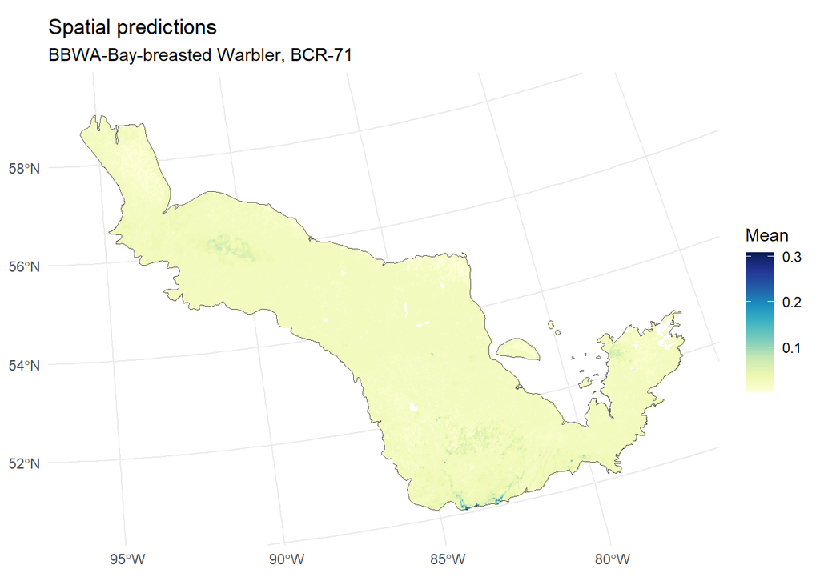

[figure not shown]

#### Extrapolation map

**Task:**

Please identify any areas that are surprising for you.

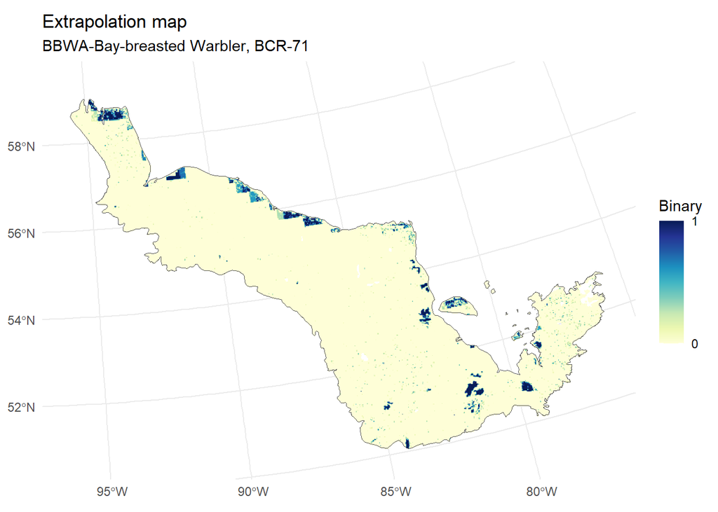

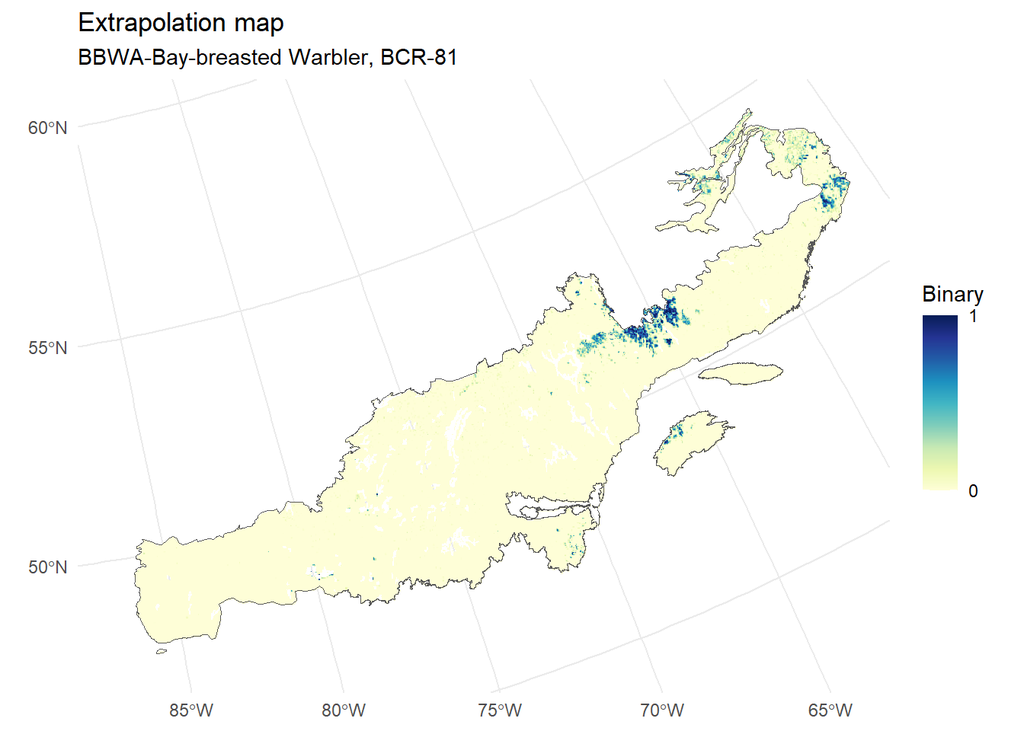

**6. Uncertainty**

#### Coefficient of variation

**Task;**

Please identify any areas that are surprising for you.

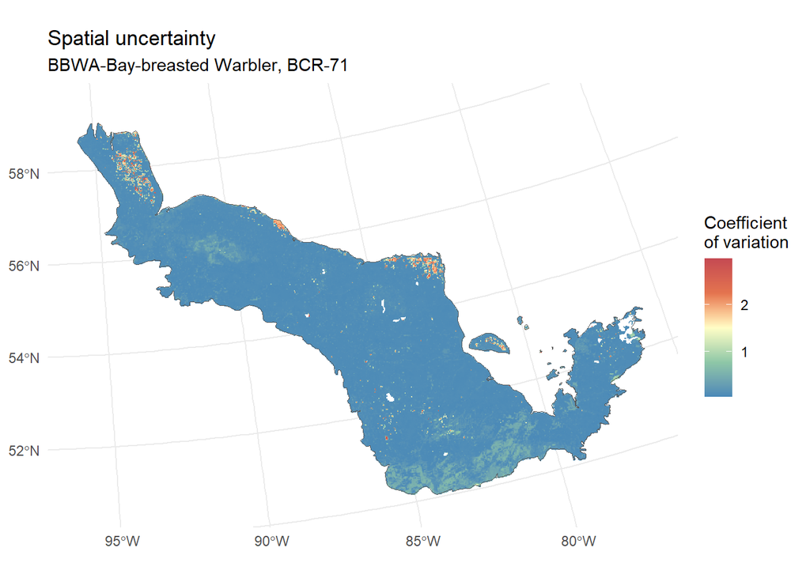

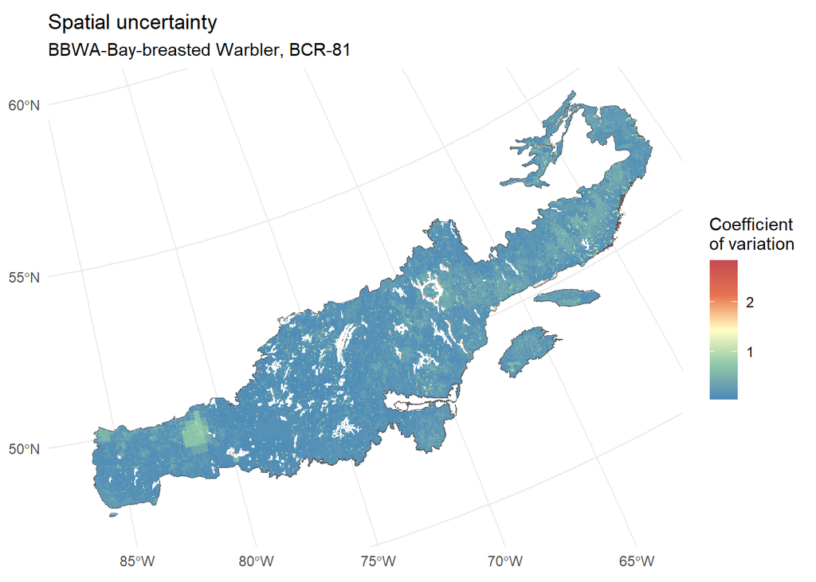